# 2.1_Tumor_airway_comparisons_cutoffs_intersections_LUAD_CSFS_20250304

2025-03-04

# Comparing and filtering A1, TE, A2, and TM to generate gene lists

## Reading in datasets to intersect

```r
# A1
GSE63127_CS_NS   <- read.table("../../2_Outputs/1_Airway_DEGs/GSE63127_CS_NS_limma_20250307.txt", header = TRUE)

# T-E
TCGA_LUAD_DEG   <- read.table("../../2_Outputs/2_Tumor_DEGs/TCGA_LUAD_limma_DEG_CSFS_20250331.txt")

# A2
GSE7895_persistent_DEGs   <- read.table("../../2_Outputs/1_Airway_DEGs/GSE7895_persistent_DEGs_quantile_20250307.txt")

# T-M
TCGA_LUAD_DMG    <- read.table("../../2_Outputs/3_Tumor_DMGs/TCGA_LUAD_limma_DMG_CSFS_20250307.txt")
```

2025/05/23: Here I am using the sequential filtering method because the last two filtering steps generate more overlap than expected by chance via the Fisher’s exact test.

This is the method I was using in a sequential pipeline to try to test each assumption being made along the way. I arbitrarily picked a 75th percentile log2FC cutoff – the test results were the same (significant) even with a much less stringent cutoff, interestingly.

## Using sequential filtering with 75th percentiles

```r
library(dplyr)
### First format them all the same way (this time not filtering for FDR)
A1_formatted <- GSE63127_CS_NS %>%
  dplyr::rename(., Gene = Gene.symbol, FDR_A1 = adj.P.Val, log2FC_A1 = logFC) %>%
  dplyr::select(., Gene, FDR_A1, log2FC_A1)

LUAD_TE_formatted<- TCGA_LUAD_DEG %>%
  dplyr::rename(., FDR_TE = FDR, log2FC_TE = log2FC, Gene = Gene) %>%
  dplyr::select(., Gene, FDR_TE, log2FC_TE)

LUAD_TM_formatted <- TCGA_LUAD_DMG %>%
  dplyr::rename(., FDR_TM = FDR, log2FC_TM = log2FC) %>%
  dplyr::select(., Gene, FDR_TM, log2FC_TM)


print("Filter 1: Shared gene symbols between A1 and TE")
```

```
## [1] "Filter 1: Shared gene symbols between A1 and TE"
```

```r
LUAD_A1_TE_shared_genes <- A1_formatted %>%
  dplyr::filter(Gene %in% intersect(LUAD_TE_formatted$Gene, A1_formatted$Gene))
nrow(LUAD_A1_TE_shared_genes)
```

```
## [1] 14941
```

```r
LUAD_TE_A1_shared_genes <- LUAD_TE_formatted %>%
  dplyr::filter(Gene %in% intersect(LUAD_TE_formatted$Gene, A1_formatted$Gene))
nrow(LUAD_TE_A1_shared_genes)
```

```
## [1] 14944
```

```r
# Note: The genes that end up being duplicates here are "DNAJC9-AS1", "POLR2J4", "RGS5", hence the difference in nrow for the two above, however I think these get lost in later steps so it does not really matter here.

print("Filter 2: FDR <= 0.05 individually for A1 and TE")
```

```
## [1] "Filter 2: FDR <= 0.05 individually for A1 and TE"
```

```r
LUAD_A1_TE_sig <- LUAD_A1_TE_shared_genes %>%
  filter(FDR_A1 <= 0.05)
nrow(LUAD_A1_TE_sig)
```

```
## [1] 5899
```

```r
LUAD_TE_A1_sig <- LUAD_TE_A1_shared_genes %>%
  filter(FDR_TE <= 0.05)
nrow(LUAD_TE_A1_sig)
```

```
## [1] 9508
```

```r
print("Filter 3: FDR <= 0.05  in both A1 and TE")
```

```
## [1] "Filter 3: FDR <= 0.05  in both A1 and TE"
```

```r
LUAD_A1_TE_sig_all <- LUAD_A1_TE_sig %>%
  filter(Gene %in% LUAD_TE_A1_sig$Gene)
nrow(LUAD_A1_TE_sig_all)
```

```
## [1] 3755
```

```r
LUAD_TE_A1_sig_all <- LUAD_TE_A1_sig %>%
  filter(Gene %in% LUAD_A1_TE_sig$Gene)
nrow(LUAD_A1_TE_sig_all)
```

```
## [1] 3755
```

```r
print("Filter 4: 75th percentile |log2FC| in each")
```

```
## [1] "Filter 4: 75th percentile |log2FC| in each"
```

```r
## A1
# Calculate percentile cutoffs
top_cutoff_A1 <- quantile(LUAD_A1_TE_sig_all$log2FC_A1, 0.875, na.rm = TRUE)  # Top 12.5%
bottom_cutoff_A1 <- quantile(LUAD_A1_TE_sig_all$log2FC_A1, 0.125, na.rm = TRUE)  # Bottom 12.5%

# Filter genes in the top and bottom 25% of log2FC
LUAD_A1_TE_percentile <- LUAD_A1_TE_sig_all %>%
  filter(log2FC_A1 >= top_cutoff_A1 | log2FC_A1 <= bottom_cutoff_A1)
nrow(LUAD_A1_TE_percentile)
```

```
## [1] 940
```

```r
###

## TE
# Calculate percentile cutoffs
top_cutoff_TE <- quantile(LUAD_TE_A1_sig_all$log2FC_TE, 0.875, na.rm = TRUE)  # Top 12.5%
bottom_cutoff_TE <- quantile(LUAD_TE_A1_sig_all$log2FC_TE, 0.125, na.rm = TRUE)  # Bottom 12.5%

# Filter genes in the top and bottom 25% of log2FC
LUAD_TE_A1_percentile <- LUAD_TE_A1_sig_all %>%
  filter(log2FC_TE >= top_cutoff_TE | log2FC_TE <= bottom_cutoff_TE)
nrow(LUAD_TE_A1_percentile)
```

```
## [1] 940
```

```r
###

print("Filter 5: 75th percentile |log2FC| in both")
```

```
## [1] "Filter 5: 75th percentile |log2FC| in both"
```

```r
LUAD_A1_TE_merged_percentile <- LUAD_A1_TE_percentile %>%
  inner_join(., LUAD_TE_A1_percentile, by = "Gene")
nrow(LUAD_A1_TE_merged_percentile)
```

```
## [1] 450
```

```r
print("Filter 6: Same sign for log2FC")
```

```
## [1] "Filter 6: Same sign for log2FC"
```

```r
LUAD_A1_TE_merged_percentile_sign <- LUAD_A1_TE_merged_percentile %>%
  filter(sign(log2FC_A1)==sign(log2FC_TE)) # Filter to genes with same signs
nrow(LUAD_A1_TE_merged_percentile_sign)
```

```
## [1] 280
```

```r
## Save this list of LUAD-A1-TE genes
#write.table(LUAD_A1_TE_merged_percentile_sign, "../2_Outputs/4_Linked_genes/LUAD_A1_TE_20250514.txt")

print("Merge with A2, same sign")
```

```
## [1] "Merge with A2, same sign"
```

```r
LUAD_A1_TE_A2 <- LUAD_A1_TE_merged_percentile_sign %>%
  inner_join(., GSE7895_persistent_DEGs, by = "Gene") %>%
  filter(sign(log2FC_A1)==sign(CS_NS_A2)) # Filter to genes with same sign
nrow(LUAD_A1_TE_A2)
```

```
## [1] 18
```

```r
# Save this list of LUAD-A1-TE-A2 genes
#write.table(LUAD_A1_TE_A2, "../2_Outputs/4_Linked_genes/LUAD_A1_TE_A2_20250514.txt")
```

## Hypergeometric tests for different filter steps

```r
print("Testing filter step 3")
```

```
## [1] "Testing filter step 3"
```

```r
N = nrow(LUAD_A1_TE_shared_genes) # All gene symbols shared between A1 and TE (filter step 1)
print(paste0("N = ",N))
```

```
## [1] "N = 14941"
```

```r
n = nrow(LUAD_A1_TE_sig) # Number of genes with FDR <= 0.05 in A1 (filter step 3)
print(paste0("n = ",n))
```

```
## [1] "n = 5899"
```

```r
m = nrow(LUAD_TE_A1_sig)  # Number of genes with FDR <= 0.05 in TE (filter step 3)
print(paste0("m = ",m))
```

```
## [1] "m = 9508"
```

```r
k  = nrow(LUAD_A1_TE_sig_all) # Number of genes with FDR <= 0.05 in both A1 and TE
print(paste0("k = ",k))
```

```
## [1] "k = 3755"
```

```r
p_value <- phyper(k - 1, m, N - m, n, lower.tail = FALSE)
print(paste0("p_value: ", p_value))
```

```
## [1] "p_value: 0.492429510712753"
```

```r
print("Testing last filter step (basically steps 5 and 6 are combined together)")
```

```
## [1] "Testing last filter step (basically steps 5 and 6 are combined together)"
```

```r
N = nrow(LUAD_A1_TE_sig_all) # The number of genes with FDR <= 0.05 in both A1 and TE (after filter step 3)
print(paste0("N = ",N))
```

```
## [1] "N = 3755"
```

```r
n = nrow(LUAD_A1_TE_percentile) # Number of genes for top 75th percentile |log2FC| in each (here A1)
print(paste0("n = ",n))
```

```
## [1] "n = 940"
```

```r
m = nrow(LUAD_TE_A1_percentile)  # Number of genes for top 75th percentile |log2FC| in each (here TE)
print(paste0("m = ",m))
```

```
## [1] "m = 940"
```

```r
k  = nrow(LUAD_A1_TE_merged_percentile_sign) # Number of genes with top 75th percentile in both and with same sign
print(paste0("k = ",k))
```

```
## [1] "k = 280"
```

```r
p_value <- phyper(k - 1, m, N - m, n, lower.tail = FALSE)
print(paste0("p_value: ", p_value))
```

```
## [1] "p_value: 7.28599142979121e-05"
```

```r
## Good, looks like the overlap is way more than expected by chance at this step, at least
```

I don’t think that the hypergeometric test can apply to checking the A2 overlap step, because A1 and A2 are not truly independent. Since they both measure genes with expression affected by smoking in airways (A1 in current smokers and A2 in former smokers), they will be expected to share many genes.

## Comparing and filtering A2 and “linked” genes to give “methylation related linked genes”

### Filtering by dataset intersection

```r
# First filter for FDR < 0.05
LUAD_TM_sig <- LUAD_TM_formatted %>%
  filter(FDR_TM <= 0.05)

# Then filter for 75th percentile
top_cutoff_TM <- quantile(LUAD_TM_sig$log2FC_TM, 0.875, na.rm = TRUE)  # Top 12.5%
bottom_cutoff_TM <- quantile(LUAD_TM_sig$log2FC_TM, 0.125, na.rm = TRUE)  # Bottom 12.5%

# Filter genes in the top and bottom 25% of log2FC
LUAD_TM_sig_percentile <- LUAD_TM_sig %>%
  filter(log2FC_TM >= top_cutoff_TM | log2FC_TM <= bottom_cutoff_TM)
nrow(LUAD_TM_sig_percentile)
```

```
## [1] 1650
```

```r
LUAD_A1_TE_A2_TM <- LUAD_A1_TE_A2 %>%
  dplyr::inner_join(., LUAD_TM_sig_percentile, by = "Gene") %>%
  dplyr::filter(sign(log2FC_A1) != sign(log2FC_TM)) # Ensure signs are opposite
nrow(LUAD_A1_TE_A2_TM)
```

```
## [1] 4
```

```r
LUAD_A1_TE_A2_TM$Gene
```

```
## [1] "GMDS" "GPX2" "LMO2" "NQO1"
```

```r
## Save
#writeLines(LUAD_A1_TE_A2_TM$Gene, "../../2_Outputs/4_Linked_genes/LUAD_A1_TE_A2_TM_genes_20250528.txt")
write.table(LUAD_A1_TE_A2_TM, "../../2_Outputs/4_Linked_genes/LUAD_A1_TE_A2_TM_20250610.txt")
```

extra stuff

I want to try Dr. DeBoer’s suggestion of linear correlations and PCA.

## Plotting log2FCs of FDR<0.05 genes from A1 and TE

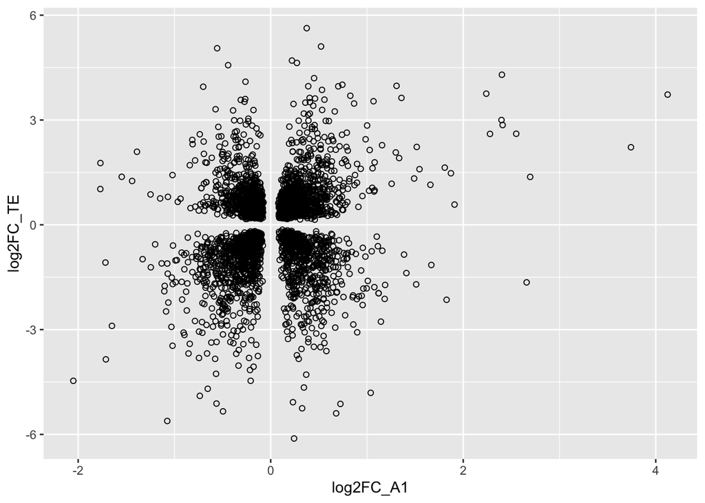

```r
library(ggplot2)


## Combine them together
A1_TE <- LUAD_A1_TE_sig_all %>%
  left_join(., LUAD_TE_A1_sig_all, by = "Gene")

## Scatterplot
ggplot(A1_TE, aes(x = log2FC_A1, y = log2FC_TE)) +
         geom_point(shape = 1)
```

```r
### Spearman correlation ###
cor_test <- cor.test(A1_TE$log2FC_A1, A1_TE$log2FC_TE, method = "spearman")
cor_test
```

```
##
##  Spearman's rank correlation rho
##
## data:  A1_TE$log2FC_A1 and A1_TE$log2FC_TE
## S = 7580768970, p-value < 2.2e-16
## alternative hypothesis: true rho is not equal to 0
## sample estimates:
##       rho
## 0.1409178
```

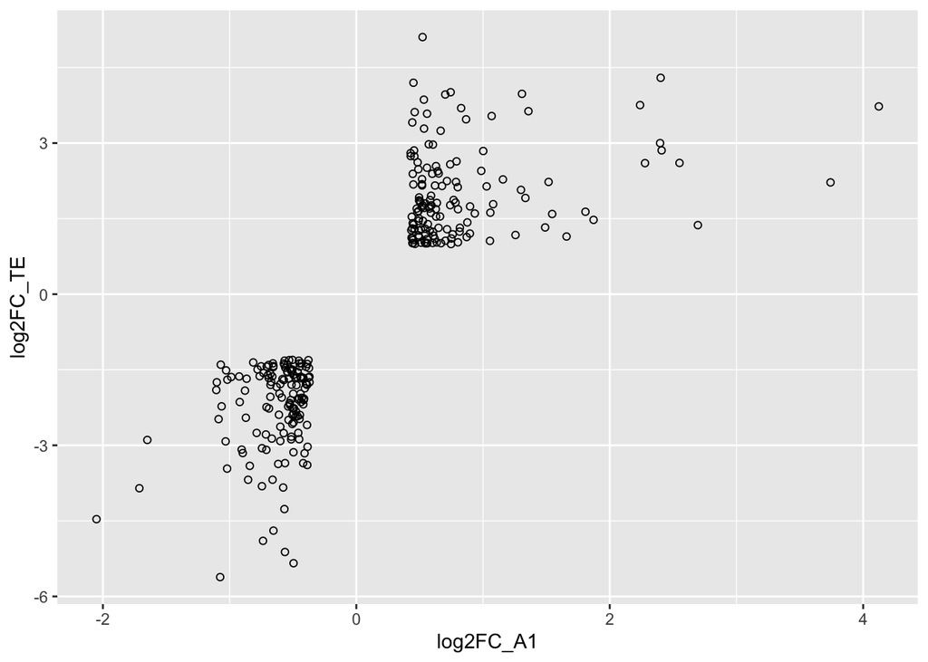

```r
# Interesting, it is highly significant? How? It doesn't look like it could be...


### Trying for the filtered genes (I mean obviously they will correlate because of the filtering selections):
ggplot(LUAD_A1_TE_merged_percentile_sign, aes(x = log2FC_A1, y = log2FC_TE)) +
         geom_point(shape = 1)
```

```r
#Even this barely looks correlated... not that it necessarily needs to be...
```